# Mitochondrial drift analysis (blood)

Mike Spencer Chapman

2026-09-16

Read in the blood mitochondrial mutation data for the analysis.

```r
source(here::here("config.R")) #sets root_dir, genomeFile, project paths and my_markdown_theme
set_markdown_figure_defaults() #larger default figure size for on-screen reading
plots_dir=notebook_plots_dir("Mitochondrial_drift_analysis")
source(paste0(root_dir,"/data/mito_mutations_blood_functions.R"))
mito_data_file=paste0(root_dir,"/data/mito_data.Rds")
ref_file=paste0(root_dir,"/data/Samples_metadata_ref.csv")

mito_data<-readRDS(mito_data_file)
ref_df=read.csv(ref_file)%>%filter(Dataset!="Lymphocyte")
Individual_cols=RColorBrewer::brewer.pal(12,"Paired")
names(Individual_cols)<-ref_df$Sample[order(ref_df$Age)]

#Read in the mutation signature by VAF and sample data
exposures<-read.csv(paste0(root_dir,"/data/mutational_signatures/exposures.csv"))
components<-read.csv(paste0(root_dir,"/data/mutational_signatures/components.csv"))
mutation_profiles_mat=read.table(paste0(root_dir,"/data/mutational_signatures/trinuc_mut_mat.txt"))
sig_ref<-readRDS(file=paste0(root_dir,"/data/mutational_signatures/sig_ref_file.Rds"))

#Clean up the row and column names
sub_vec = c("C>A","C>G","C>T","T>A","T>C","T>G"); ctx_vec = paste(rep(c("A","C","G","T"),each=4),rep(c("A","C","G","T"),times=4),sep="-")
full_vec = paste(rep(sub_vec,each=16),rep(ctx_vec,times=6),sep=",")
colnames(components)<-c(paste(full_vec,"H",sep="_"),paste(full_vec,"L",sep="_"))
rownames(components)<-paste0("N",0:(nrow(components)-1))
rownames(exposures)<-paste0("N",0:(nrow(exposures)-1))
colnames(exposures)<-gsub("^X","",colnames(exposures))
colnames(exposures)<-gsub("\\.pcw"," pcw",colnames(exposures))

#Set the basic plotting theme for ggplot2
#my_markdown_theme is defined in config.R

#my_markdown_theme is defined in config.R
```

```r
VAF_groups_original=unique(sapply(stringr::str_split(colnames(exposures),pattern="_"),function(vec) paste(vec[2:3],collapse="_")))
new_VAF_groups=c("<0.1%","0.1-0.2%","0.2-0.4%","0.4-0.8%","0.8-1.6%","1.6-3.1%","3.1-6.2%","6.2-12.5%","12.5-25%","25-50%",">50%")
names(new_VAF_groups)<-VAF_groups_original

#Define the VAF 'bins' that will be used for comparing VAF distributions
VAF_groups=data.frame(
  labels=new_VAF_groups,
  lower_limit=c(0,2^(-10:-1)),
  upper_limit=2^(-10:0)
)

VAF_groups
```

```
##                             labels  lower_limit  upper_limit
## 0_0.0009765625               <0.1% 0.0000000000 0.0009765625
## 0.0009765625_0.001953125  0.1-0.2% 0.0009765625 0.0019531250
## 0.001953125_0.00390625    0.2-0.4% 0.0019531250 0.0039062500
## 0.00390625_0.0078125      0.4-0.8% 0.0039062500 0.0078125000
## 0.0078125_0.015625        0.8-1.6% 0.0078125000 0.0156250000
## 0.015625_0.03125          1.6-3.1% 0.0156250000 0.0312500000
## 0.03125_0.0625            3.1-6.2% 0.0312500000 0.0625000000
## 0.0625_0.125             6.2-12.5% 0.0625000000 0.1250000000
## 0.125_0.25                12.5-25% 0.1250000000 0.2500000000
## 0.25_0.5                    25-50% 0.2500000000 0.5000000000
## 0.5_1                         >50% 0.5000000000 1.0000000000
```

```r
mut_numbers=data.frame(SampleID=rownames(mutation_profiles_mat),nmuts=rowSums(mutation_profiles_mat))

#Fill in the rare bins with too low mutation numbers - assume all are N1, as these are high VAF mutations
# (in samples with adequate mutations for extraction, high VAF mutations are all N1)
excluded_cats<-rownames(mutation_profiles_mat)[!rownames(mutation_profiles_mat)%in%colnames(exposures)]
all_N1=c(0,1,rep(0,nrow(exposures)-2))
excluded_mat<-matrix(rep(all_N1,times=length(excluded_cats)),nrow=length(all_N1),dimnames = list(rownames(exposures),excluded_cats))

real_muts_dist_df<-t(cbind(exposures,excluded_mat))%>%
  as.data.frame()%>%
  tibble::rownames_to_column(var="SampleID")%>%
  left_join(mut_numbers)%>%
  mutate(exp_ID=stringr::str_split(SampleID,pattern="_",simplify=T)[,1])%>%
  mutate(VAF_range=sapply(stringr::str_split(SampleID,pattern="_"),function(vec) paste(vec[2:3],collapse="_")))%>%
  mutate(VAF_range=factor(new_VAF_groups[VAF_range],levels=new_VAF_groups))%>%
  dplyr::select(-SampleID)%>%
  gather(-VAF_range,-exp_ID,-nmuts,key="Signature",value="Exposure")%>%
  mutate(abs_muts=Exposure*nmuts)%>%
  mutate(Signature=factor(Signature,levels=c(rownames(exposures)[nrow(exposures):3],"N0","N1")))%>%
  dplyr::filter(Signature=="N1")%>%
  mutate(exp_ID=gsub("8 pcw","8pcw",exp_ID))
head(real_muts_dist_df)
```

```
##   nmuts exp_ID VAF_range Signature    Exposure   abs_muts
## 1    76  CB001     <0.1%        N1 0.003500000  0.2660000
## 2   524  CB001  0.1-0.2%        N1 0.027001272 14.1486667
## 3   349  CB001  0.2-0.4%        N1 0.152536772 53.2353333
## 4   100  CB001  0.4-0.8%        N1 0.539296667 53.9296667
## 5    57  CB001  0.8-1.6%        N1 0.971532164 55.3773333
## 6    85  CB002     <0.1%        N1 0.001478431  0.1256667
```

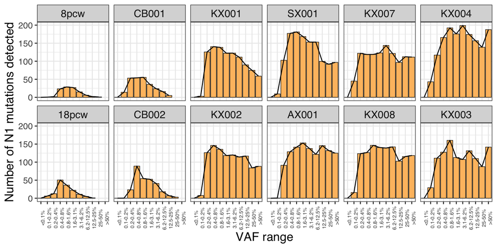

```r
real_mut_distribution_plot<-real_muts_dist_df%>%
  ggplot(aes(x=VAF_range,y=abs_muts))+
  geom_bar(stat="identity",fill="#FDBF6F",col="black",linewidth=0.25)+
  geom_line(aes(group=exp_ID))+
  theme_bw()+
  my_markdown_theme+
  theme(axis.text.x = element_text(size = 6,angle=90),strip.text.x = element_text(size = 12))+
  #facet_grid(rows=vars(factor(exp_ID,levels=ref_df$Sample[order(ref_df$Age)])),scales="free")+
  facet_wrap(~factor(exp_ID,levels=ref_df$Sample[order(ref_df$Age)]),scales="fixed",dir="v",ncol=6)+
  labs(x="VAF range",y="Number of N1 mutations detected")

real_mut_distribution_plot+my_markdown_theme+theme(strip.text.x = element_text(size = 12),axis.text.x = element_text(size = 6,angle=90))
```

Normalize mutation numbers by the number of samples included.

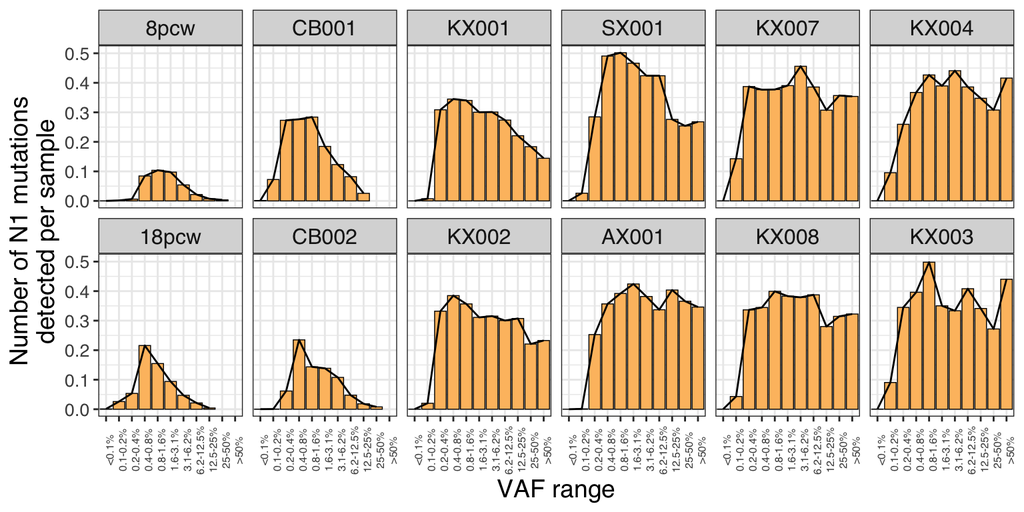

```r
nsamp_df<-Map(list=mito_data,Exp_ID=names(mito_data),function(list,Exp_ID) {
  data.frame(exp_ID=Exp_ID,n_samp=length(colnames(list$matrices$SW)))
})%>%dplyr::bind_rows()%>%
  mutate(exp_ID=gsub("8 pcw","8pcw",exp_ID))

real_mut_distribution_plot_normalized<-left_join(real_muts_dist_df,nsamp_df)%>%
  mutate(muts_per_samp=abs_muts/n_samp)%>%
  ggplot(aes(x=VAF_range,y=muts_per_samp))+
  geom_bar(stat="identity",fill="#FDBF6F",col="black",linewidth=0.25)+
  geom_line(aes(group=exp_ID))+
  theme_bw()+
  my_markdown_theme+
  theme(axis.text.x = element_text(size = 6,angle=90),strip.text.x = element_text(size = 12))+
  #facet_grid(rows=vars(factor(exp_ID,levels=ref_df$Sample[order(ref_df$Age)])),scales="free")+
  facet_wrap(~factor(exp_ID,levels=ref_df$Sample[order(ref_df$Age)]),scales="fixed",dir="v",ncol=6)+
  labs(x="VAF range",y="Number of N1 mutations\ndetected per sample")
real_mut_distribution_plot_normalized+my_markdown_theme+theme(strip.text.x = element_text(size = 12),axis.text.x = element_text(size = 6,angle=90))
```

```r
save_plot(filename=paste0(plots_dir,"real_mut_distribution_plot.pdf"),real_mut_distribution_plot_normalized,width=7,height=2.5)
```

```r
sumstats.data<-left_join(real_muts_dist_df,nsamp_df)%>%
  mutate(muts_per_samp=abs_muts/n_samp)%>%
  dplyr::select(exp_ID,VAF_range,muts_per_samp)%>%
  pivot_wider(names_from="VAF_range",values_from="muts_per_samp")%>%
  replace(is.na(.), 0)
head(sumstats.data)
```

```
## # A tibble: 6 × 12
##   exp_ID  `<0.1%` `0.1-0.2%` `0.2-0.4%` `0.4-0.8%` `0.8-1.6%` `1.6-3.1%`
##   <chr>     <dbl>      <dbl>      <dbl>      <dbl>      <dbl>      <dbl>
## 1 CB001  0.00136    0.0726       0.273       0.277      0.284      0.185
## 2 CB002  0.000332   0.000618     0.0617      0.235      0.144      0.139
## 3 KX001  0.000103   0.00742      0.309       0.345      0.340      0.300
## 4 KX002  0.000446   0.0202       0.332       0.385      0.357      0.311
## 5 KX003  0.000441   0.0905       0.345       0.396      0.498      0.350
## 6 KX004  0.000525   0.0955       0.260       0.367      0.427      0.389
## # ℹ 5 more variables: `3.1-6.2%` <dbl>, `6.2-12.5%` <dbl>, `12.5-25%` <dbl>,
## #   `25-50%` <dbl>, `>50%` <dbl>
```

### VISUALIZE WRIGHT-FISHER MODELS OF DRIFT

This code is to plot the shifting distribution of VAFs over time - single run of simulation but storing information after each generation

```r
muts_per_mitochondria_per_generation=5e-4
print(muts_per_mitochondria_per_generation)
```

```
## [1] 5e-04
```

```r
mito_copy_number=600 #This is the
number_of_cells_in_simulation=1000 #Need enough 'cells' to have adequate mutation numbers to define the distribution
mutation_introductions_per_generation=muts_per_mitochondria_per_generation*number_of_cells_in_simulation*mito_copy_number
```

Record the distribution of VAFs every 10 generations, though the generation of mutation acquisition is recorded exactly.

```r
gens_to_include=seq(10,1500,10)
gens_record=vector(mode="list",length = length(gens_to_include))
vaf_by_gen_list=vector(mode="list")
last_gen=0
curr_vafs=c()
for(ngen in gens_to_include) {
  #print(ngen)
  if(length(vaf_by_gen_list)>0) {
    drifted_old_muts=lapply(vaf_by_gen_list,function(gen_vafs) {
      new_gen_vafs<-sapply(gen_vafs,function(vaf) fisher_wright_drift(vaf,population_size = mito_copy_number,1,ngen-last_gen))
      return(new_gen_vafs[new_gen_vafs>0])
    })
  } else {
    drifted_old_muts<-NULL
  }

  new_muts_gen_list=vector(mode="list",length=ngen-last_gen)
  names(new_muts_gen_list)<-(last_gen+1):ngen
  for(j in 1:(ngen-last_gen)){
    gen_mut_vafs<-vector(length=mutation_introductions_per_generation)
    for(i in 1:mutation_introductions_per_generation) {
      this_mut_final_vaf<- fisher_wright_drift(1/mito_copy_number,population_size = mito_copy_number,1,j)
      gen_mut_vafs[i]<-this_mut_final_vaf
    }
    new_muts_gen_list[[j]]<-gen_mut_vafs[gen_mut_vafs>0]
  }
  vaf_by_gen_list<-c(drifted_old_muts,new_muts_gen_list)
  gen_summary=Map(vafs=vaf_by_gen_list,gen=names(vaf_by_gen_list),function(vafs,gen) if(length(vafs)>0){data.frame(gen=gen,vaf=vafs)}else {NULL})%>%dplyr::bind_rows()%>%mutate(total_gens=ngen)
  gens_record[[which(gens_to_include==ngen)]]<-gen_summary
  last_gen<-ngen
}
```

Here, 7.5 is the ‘haploid sequencing coverage’ in this simulated experiment. This approximates the ~15X diploid coverage of most of the experiments.

```r
haploid_coverage=7.5
gens_record<-dplyr::bind_rows(gens_record)
gens_record$observed_vaf=sapply(gens_record$vaf,function(vaf) rbinom(n=1,size=(haploid_coverage*mito_copy_number),prob=vaf)/(haploid_coverage*mito_copy_number))

gens_record$VAF_group=sapply(1:nrow(gens_record),function(i) {
  if(gens_record$observed_vaf[i]==0) {
    return("Absent")
  } else {
    return(VAF_groups$labels[VAF_groups$lower_limit<gens_record$observed_vaf[i] & VAF_groups$upper_limit>=gens_record$observed_vaf[i]])
  }
})
```

Visualize the distribution at a selection of “generations” to get a sense of the evolution of the distribution through time. Note that the colouring of a mutation tells you when in life it was actually acquired. Red mutations were acquired very early in life, whereas blue mutations were acquired late. This demonstrates that while low VAF mutations were invariably acquired recently, high VAF mutations are usually acquired decades ago, but there aren’t very many until late in life.

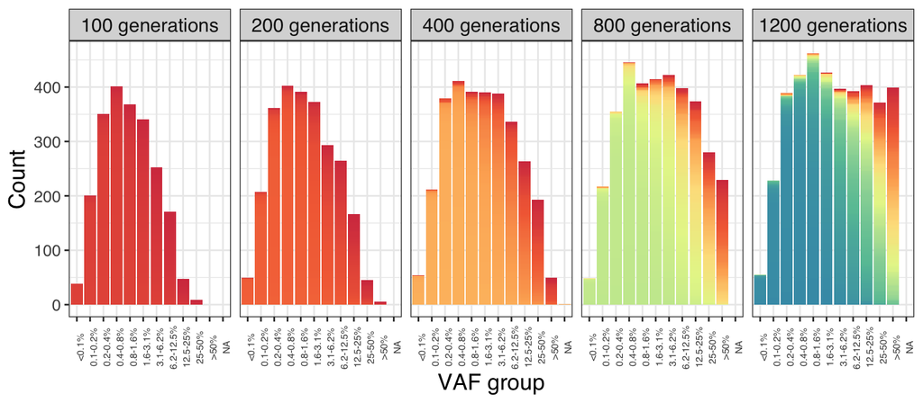

```r
modelled_VAF_dist<-gens_record%>%
  filter(total_gens%in%c(100,200,400,800,1200))%>%
  mutate(total_gens=factor(paste(total_gens,"generations"),levels=paste(c(100,200,400,800,1200),"generations")))%>%
  mutate(VAF_group=factor(VAF_group,levels=new_VAF_groups),gen=factor(gen,levels=1:1200))%>%
  ggplot(aes(x=VAF_group,fill=gen))+
  geom_bar(stat="count")+
  facet_wrap(~total_gens,ncol=5)+
  theme_bw()+
  theme(legend.position = "none",axis.text.x = element_text(size = 6,angle=90),strip.text.x = element_text(size = 12))+
  scale_fill_manual(values = colorRampPalette(RColorBrewer::brewer.pal(8,"Spectral"))(1200))+
  labs(x="VAF group",y="Count")+
  my_markdown_theme

modelled_VAF_dist+my_markdown_theme+theme(strip.text.x = element_text(size = 12),axis.text.x = element_text(size = 6,angle=90))
```

```r
save_plot(filename=paste0(plots_dir,"Modelled_VAF_dist.pdf"),modelled_VAF_dist,width = 6,height=2)
```

How many ‘high VAF’ (>50%) mutaitons are there depending on the generation?

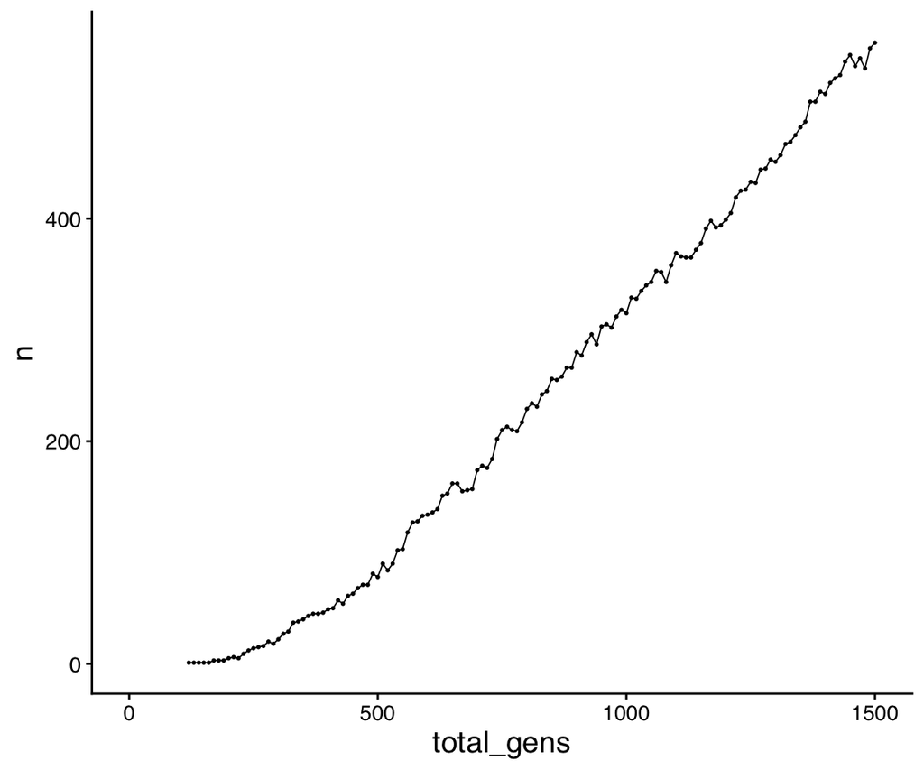

```r
gens_record%>%
  filter(VAF_group==">50%")%>%
  #mutate(total_gens=factor(total_gens,levels=seq(10,1500,10)))%>%
  dplyr::group_by(total_gens)%>%
  summarise(n=n(),.groups = "drop_last")%>%
  ggplot(aes(x=total_gens,y=n))+
  scale_x_continuous(limits=c(0,1500))+
  geom_point(size=0.3)+
  geom_line(linewidth=0.3)+
  theme_classic()+
  my_markdown_theme
```

One notable feature is that these simulations suggest that high VAF mutations were acquired early in life. Conversely, low VAF mutations were invariably acquired very recently.

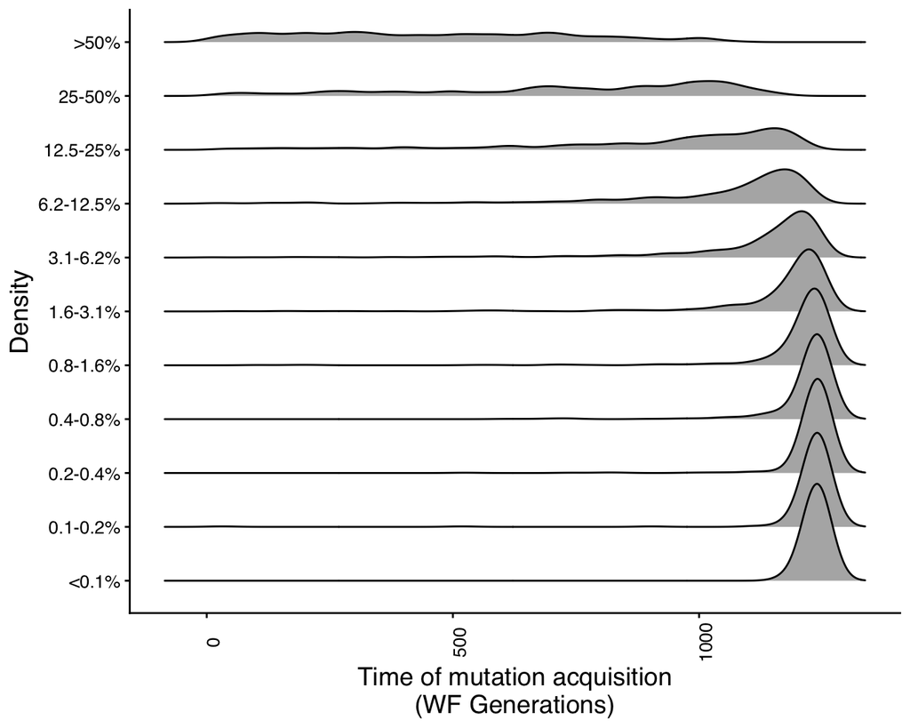

```r
acquisition_time_by_VAF<-gens_record%>%
  mutate(VAF_group=factor(VAF_group,levels=VAF_groups$labels))%>%
  filter(total_gens==1250)%>%
  ggplot(aes(x=as.numeric(gen),y=VAF_group))+
  ggridges::geom_density_ridges(panel_scaling = F)+
  theme_classic()+
  my_markdown_theme+
  theme(axis.text.x=element_text(angle=90),strip.text.x = element_text(size = 14,margin = unit(c(1,0,1,0),"mm")))+
  labs(x="Time of mutation acquisition\n(WF Generations)",y="Density")
acquisition_time_by_VAF+my_markdown_theme
```

```r
save_plot(filename = paste0(plots_dir,"Acquisition_time_by_VAF.pdf"),acquisition_time_by_VAF,width=7,height=2.5)
```

Plot same data but as a ridges plot.

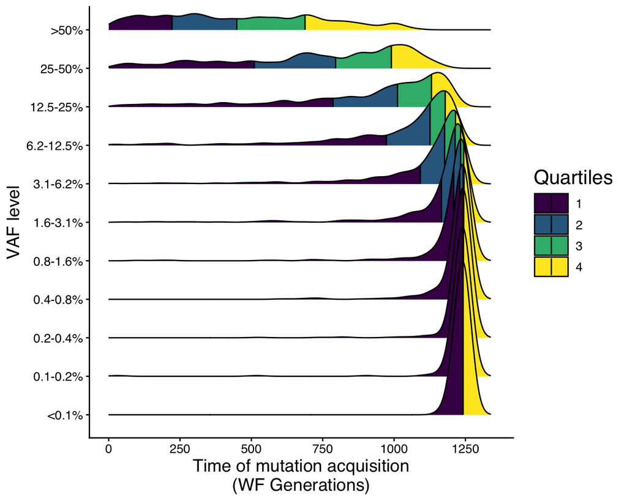

```r
acquisition_time_by_VAF_ridges<-gens_record%>%
  mutate(VAF_group=factor(VAF_group,levels=VAF_groups$labels))%>%
  filter(total_gens==1250)%>%
  ggplot(aes(x=as.numeric(gen),y=VAF_group,fill = factor(stat(quantile),levels=1:4))) +
  stat_density_ridges(geom = "density_ridges_gradient", calc_ecdf = TRUE,quantiles = 4, quantile_lines = TRUE,scale=4) +
  scale_fill_viridis_d(name = "Quartiles")+
  scale_x_continuous(limits=c(0,1350),breaks=seq(0,1250,250))+
  theme_classic()+
  my_markdown_theme+
  labs(x="Time of mutation acquisition\n(WF Generations)",y="VAF level")

acquisition_time_by_VAF_ridges+my_markdown_theme
```

```r
save_plot(filename = paste0(plots_dir,"acquisition_time_by_VAF_ridges.pdf"),acquisition_time_by_VAF_ridges,width=3.3,height=2.5)
```

### Animation of the Wright-Fisher model

Can also be informative to visualize the evolving distribution over time as an animation.

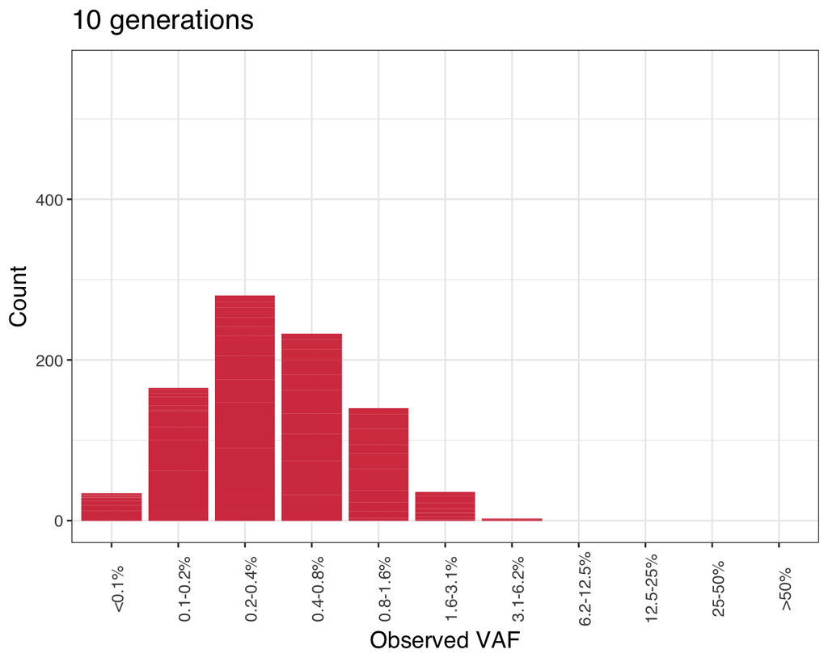

```r
gens_record_summary<-gens_record%>%
  group_by(total_gens,gen,VAF_group)%>%
  summarise(n=n(),.groups = "drop_last")
gens_record_summary$VAF_group=factor(gens_record_summary$VAF_group,levels=VAF_groups$labels)
gens_record_summary$gen=as.numeric(gens_record_summary$gen)

drift_with_age_animation<-gens_record_summary%>%
  filter(!is.na(VAF_group))%>%
  arrange(gen)%>%
  ggplot(aes(x=VAF_group,y=n,fill=gen))+
  geom_bar(stat="identity")+
  transition_manual(frames=total_gens)+
  theme_bw()+
  my_markdown_theme+
  theme(title = element_text(size = 14),legend.position = "none",axis.text.x = element_text(angle=90,size=10),axis.title.x=element_text(size = 14),axis.title.y=element_text(size = 14))+
  scale_fill_gradientn(colours = RColorBrewer::brewer.pal(8,"Spectral"))+
  labs(title='{current_frame} generations',x="Observed VAF",y="Count")

drift_with_age_animation+my_markdown_theme
```

```r
anim <- gganimate::animate(drift_with_age_animation,renderer = gifski_renderer())
save_anim(filename=paste0(plots_dir,"driftwithage.gif"),animation = anim)
```

Plot the colour scale for these figures.

```r
max_gen=1500
lut=colorRampPalette(RColorBrewer::brewer.pal(8,"Spectral"))(max_gen)
scale = (length(lut)-1)
save_pdf(paste0(plots_dir,"mito_muts_by_gen_scale.pdf"),height=6,width = 3)
plot(c(0,10), c(0,1), type='n', bty='n', xaxt='n', xlab='', yaxt='n', ylab='', main="")
axis(side=2,pos=1,las=1,at=seq(0,max_gen,200)/scale,labels=seq(0,max_gen,200))
for (i in 1:(length(lut)-1)) {
  y = (i-1)/scale
  rect(1,y,2,y+1/scale, col=lut[i], border=NA)
}
dev.off()
```

### PERFORM THE ABC - with all mutations.

This section uses summary statistics collected from many simulations and compares the results to those from the data stastics for each individual (as collected above). The actual simulations are run in the separate script “Mito_VAF_distribution_simulations.R” and saved in an Rds object.

```r
all_sumstats=readRDS(file=paste0(root_dir,"/data/Drift_ABC_VAF_distribution/VAF_distribution_ABC_simulation_sumstats_combined.Rds"))

new_VAF_groups=c("<0.1%","0.1-0.2%","0.2-0.4%","0.4-0.8%","0.8-1.6%","1.6-3.1%","3.1-6.2%","6.2-12.5%","12.5-25%","25-50%",">50%")

#Exclude the lowest VAF categories from abc that may be unreliably captured by sequencing
VAF_categories_to_include_in_ABC=new_VAF_groups[3:11]

mtDNA_CN=600
abc_res_df<-lapply(1:nrow(sumstats.data),function(i) {
  Exp_ID=sumstats.data[i,1]
  res<-abc(target = as.numeric(sumstats.data[i,VAF_categories_to_include_in_ABC]),
           param = all_sumstats[,1:2],
           sumstat = all_sumstats[,VAF_categories_to_include_in_ABC],
           tol = 0.02,
           transf = c("log","log"),
           method = "neuralnet")
  stats=apply(res$adj.values,2,quantile,c(0.025,0.5,0.975))
  stats=as.data.frame(stats)%>%tibble::rownames_to_column(var="quantile")%>%pivot_wider(names_from = "quantile",values_from=c("muts_per_mitochondria_per_generation","total_generations"))
  return(cbind(data.frame(exp_ID=Exp_ID),stats))
})%>%dplyr::bind_rows()%>%
  left_join(ref_df,by=c("exp_ID"="Sample"))
```

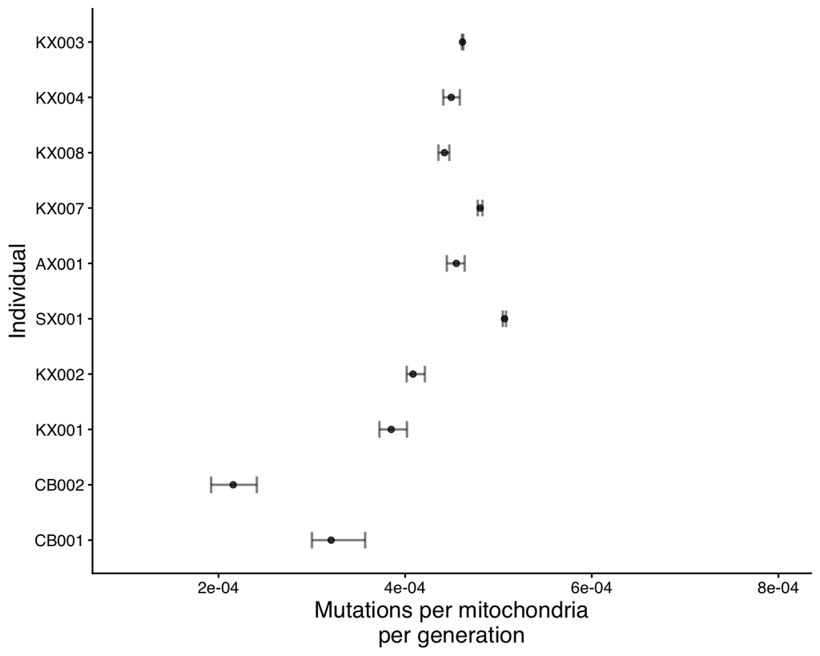

```r
abc_res_plot_mut_rate<-abc_res_df%>%
  filter(Age>=0)%>%
  ggplot(aes(x=forcats::fct_reorder(exp_ID,Age),y=`muts_per_mitochondria_per_generation_50%`,
             ymin=`muts_per_mitochondria_per_generation_2.5%`,
             ymax=`muts_per_mitochondria_per_generation_97.5%`))+
  geom_smooth(method="lm",col="black",linewidth=0.5)+
  geom_point(alpha=0.75,size=1.5)+
  geom_errorbar(width=0.3,alpha=0.5,linewidth=0.7)+
  theme_classic()+
  scale_y_continuous(limits=c(1e-4,8e-4),breaks=seq(2e-4,1e-3,2e-4))+
  labs(x="Individual",y="Mutations per mitochondria\nper generation")+
  my_markdown_theme+
  coord_flip()

abc_res_plot_mut_rate+my_markdown_theme
```

```r
save_plot(filename=paste0(plots_dir,"abc_res_plot_mut_rate.pdf"),abc_res_plot_mut_rate,width=1.75,height=2)
```

Now do linear mixed effects modelling using all values of the posterior distribution and using individual as a random effect. First, run an abc on each individual, one at a time, using neural network regression to improve the posterior distributions. Each individual is a row of the sumstats.data matrix. Then bind the posterior distribution results from each abc and add in the related metadata for each individual (primarily age). However, do not include the foetal samples as the distributions at this very early time point are likely dominated by heteroplasmic oocyte mutations which are not explicitly modelled in the simulations.

```r
abc_res_df<-lapply(1:nrow(sumstats.data),function(i) {
  Exp_ID=sumstats.data[i,1]
  res<-abc(target = as.numeric(sumstats.data[i,VAF_categories_to_include_in_ABC]),
           param = all_sumstats[,1:2],
           sumstat = all_sumstats[,VAF_categories_to_include_in_ABC],
           tol = 0.05,
           transf = c("log","log"),
           method = "neuralnet")

  return(as.data.frame(res$adj.values)%>%mutate(exp_ID=Exp_ID$exp_ID))
})%>%dplyr::bind_rows()%>%
  left_join(ref_df%>%dplyr::select(Sample,Age),by=c("exp_ID"="Sample"))%>%
  dplyr::filter(!exp_ID%in%c("8pcw","18pcw"))
```

Then perform the LMER

```r
lme.gens_by_age<-lme4::lmer(total_generations~Age+(1|exp_ID),data=abc_res_df)
summary(lme.gens_by_age)
```

```
## Linear mixed model fit by REML ['lmerMod']
## Formula: total_generations ~ Age + (1 | exp_ID)
##    Data: abc_res_df
##
## REML criterion at convergence: 24657
##
## Scaled residuals:
##     Min      1Q  Median      3Q     Max
## -7.6325 -0.3369  0.0033  0.3529  5.7188
##
## Random effects:
##  Groups   Name        Variance Std.Dev.
##  exp_ID   (Intercept) 11819    108.71
##  Residual              1095     33.09
## Number of obs: 2500, groups:  exp_ID, 10
##
## Fixed effects:
##             Estimate Std. Error t value
## (Intercept)  173.332     66.284   2.615
## Age           13.817      1.164  11.874
##
## Correlation of Fixed Effects:
##     (Intr)
## Age -0.855
```

```r
mtDNA_CN*365/lme.gens_by_age@beta[2]
```

```
## [1] 15850.08
```

```r
mtDNA_CN*365/confint(lme.gens_by_age)["Age",]
```

```
## Computing profile confidence intervals ...
```

```
##    2.5 %   97.5 %
## 18937.14 13628.43
```

Plot these results.

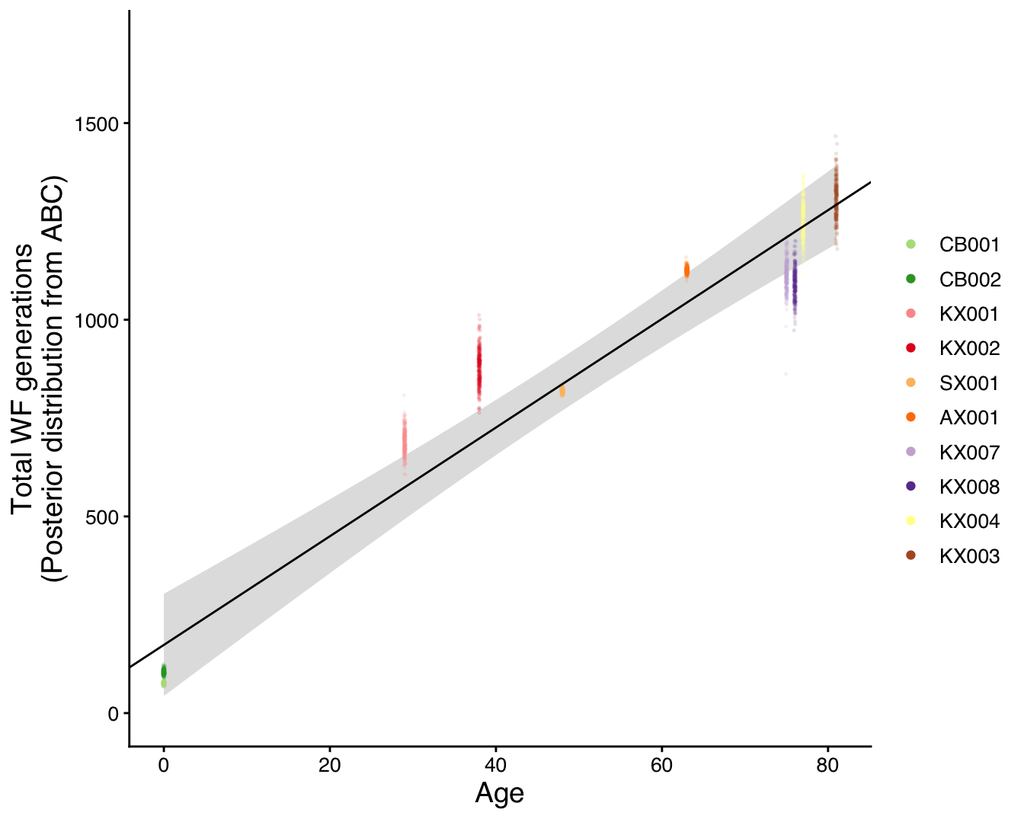

```r
#95% CI of the fitted trend - see lmer_confidence_band() for what the band covers
gens_by_age_band<-lmer_confidence_band(lme.gens_by_age,abc_res_df,predictor="Age")

abc_res_plot_total_generations<-abc_res_df%>%
  dplyr::filter(!exp_ID%in%c("8pcw","18pcw"))%>%
  mutate(exp_ID=factor(exp_ID,levels=ref_df$Sample[order(ref_df$Age)]))%>%
  ggplot(aes(x=Age,y=total_generations))+
  geom_ribbon(data=gens_by_age_band,aes(x=Age,ymin=lower,ymax=upper),
              inherit.aes=FALSE,fill="grey50",alpha=0.25)+
  geom_jitter(aes(col=exp_ID),alpha=0.1,size=0.3,width=0.1,height = 0)+
  scale_y_continuous(limits=c(0,1700))+
  geom_abline(slope=lme.gens_by_age@beta[2],intercept = lme.gens_by_age@beta[1],linetype=1)+
  scale_color_manual(values=Individual_cols[-c(1:2)])+
  theme_classic()+
  guides(colour=guide_legend(override.aes = list(alpha=1,size=1.5)))+
  labs(x="Age",y="Total WF generations\n(Posterior distribution from ABC)",col="")+
  my_markdown_theme+
  theme(legend.box.spacing = unit(0,"mm"),
        legend.key.size = unit(0.5,"mm"),
        legend.spacing = unit(0,"mm"),
        legend.box.margin = margin(c(0,0,0,0)),
        legend.text = element_text(margin = margin(t=0)))
abc_res_plot_total_generations+my_markdown_theme
```

```r
save_plot(filename=paste0(plots_dir,"abc_res_plot_total_generations.pdf"),abc_res_plot_total_generations,width=2,height=2)
```

## Now a version of the ABC with only synonymous/ non-coding mutation

This was requested by reviewers to ensure that non-synonymous mutations are not introducing a bias in drift estimates due to their positive/ negative selection which may affect the heteroplasmy distributions.

Therefore, annotate all the mutations in the data, and retain only non-coding and synonymous variants.

```r
CN_correlating_muts<-readRDS(paste0(root_dir,"/data/CN_correlation.RDS"))
length(CN_correlating_muts)
```

```
## [1] 316
```

```r
exclude_muts=c("MT_16183_A_C") #This is a specific artefact primarily in the 8pcw foetus due to a germline SNP and consequent frequent PCR slippage

#Define the VAF bins to use for signature extraction
bins=2^c(-10:0)

#Generate tidy data frame of samples, mutations and vafs
mutCN_cutoff=25 #If the mitochondrial copy number is over 25, retain mutation even if is in the "CN correlating muts" list
df_tidy<-dplyr::bind_rows(Map(list=mito_data,exp_ID=names(mito_data),function(list,exp_ID) {
  if(is.null(list)){stop(return(NULL))}
  CN_correlating_mut_removal_mat=list$matrices$implied_mutCN>mutCN_cutoff|(matrix((!rownames(list$matrices$vaf)%in%CN_correlating_muts),ncol=1)%*%matrix(rep(1,ncol(list$matrices$vaf)),nrow=1))
  implied_mut_CN_tidy<-list$matrices$implied_mutCN%>%
    as.data.frame()%>%
    tibble::rownames_to_column(var="mut_ref")%>%
    dplyr::select(-global)%>%
    tidyr::gather(key="Sample",value="implied_mut_CN",-mut_ref)
  df_tidy<-(list$matrices$vaf*list$matrices$SW*(list$matrices$ML_Sig=="N1")*CN_correlating_mut_removal_mat)%>%
    as.data.frame()%>%
    tibble::rownames_to_column(var="mut_ref")%>%
    mutate(rho_val=list$rho_vals)%>%
    dplyr::select(-global)%>%
    tidyr::gather(key="Sample",value="vaf",-mut_ref,-rho_val)

  comb_tidy<-left_join(df_tidy,implied_mut_CN_tidy,by=c("Sample","mut_ref"))%>%
    dplyr::filter(!grepl("DEL|INS",mut_ref) & !mut_ref%in%exclude_muts)%>%
    dplyr::filter(vaf>0)%>%
    mutate(exp_ID=exp_ID)
  return(comb_tidy)
}))
```

Annotate the mutations using dndscv. Excluding the missense/ nonsense/ stop loss mutations gets rid of almost half of mutations.

```r
mtref_rda_path=paste0(root_dir,"/data/mtref.rda")

#All mtDNA genes
target_genes <- c("MT-CYB", "MT-ND5", "MT-ND2", "MT-ND4", "MT-ND1", "MT-CO3", "MT-ATP6","MT-ND3", "MT-ATP8", "MT-ND4L", "MT-CO2", "MT-CO1","MT-ND5")

dndscv_input<-df_tidy%>%tidyr::separate(col=mut_ref,into = c("chr","pos","ref","alt"),sep = "_")%>%
  dplyr::select("sampleID"=Sample,chr,pos,ref,alt)

dndscv_output <- dndscv(dndscv_input,
                        gene_list=target_genes,
                        refdb = mtref_rda_path,
                        numcode=2, #numcode = 2 specifies using the mitochondrial genetic code
                        max_coding_muts_per_sample = Inf,
                        max_muts_per_gene_per_sample = Inf)

mtDNA.annotated<-dndscv_output$annotmuts%>%
  tidyr::unite(col = "mut_ref",chr,pos,ref,mut,sep = "_")%>%
  dplyr::rename("Sample"=sampleID)

df_tidy_annotated<-left_join(df_tidy,mtDNA.annotated,by=c("Sample","mut_ref"))%>%
  tidyr::replace_na(replace=list(impact="Non-coding"))
table(df_tidy_annotated$impact)
```

```
##
##   Missense Non-coding   Nonsense  Stop_loss Synonymous
##       5343       5629        271          4       1456
```

```r
df_tidy_syn_noncoding_only<-df_tidy_annotated%>%filter(impact=="Synonymous"|impact=="Non-coding")
```

Visualize the distribution of these. Note that this is visually a simlar shape to the distributions from all the mutations, but with lower absolute mutations per cell.

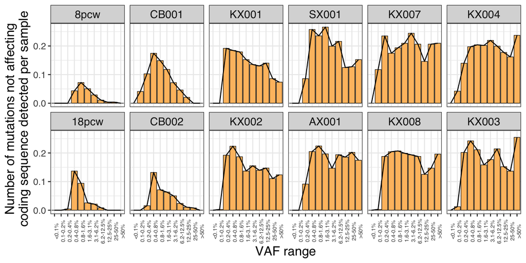

```r
syn_muts_distribution_df<-lapply(names(mito_data),function(this_exp_ID) {
  #print(this_exp_ID)
  exp_bins<-lapply(1:length(bins),function(i) {
    lower_limit=ifelse(i==1,0,bins[i-1])
    upper_limit=bins[i]
    #print(paste(lower_limit,"to",upper_limit))
    bin_exp_muts<-df_tidy_syn_noncoding_only%>%
      dplyr::filter(exp_ID==this_exp_ID & vaf>lower_limit & vaf<= upper_limit)%>%
      dplyr::distinct(exp_ID,mut_ref,.keep_all = T)%>%
      nrow()

    data.frame(exp_ID=this_exp_ID,VAF_range=VAF_groups$labels[i],Signature="N1",abs_muts=bin_exp_muts)
  })
  return(exp_bins)
})%>%dplyr::bind_rows()

#Bind together mutation sets & annotate the trinucleotide context
real_syn_mut_distribution_plot_normalized<-left_join(syn_muts_distribution_df,nsamp_df)%>%
  mutate(muts_per_samp=abs_muts/n_samp,VAF_range=factor(VAF_range,levels=new_VAF_groups))%>%
  ggplot(aes(x=VAF_range,y=muts_per_samp))+
  geom_bar(stat="identity",fill="#FDBF6F",col="black",linewidth=0.25)+
  geom_line(aes(group=exp_ID))+
  theme_bw()+
  my_markdown_theme+
  theme(axis.text.x = element_text(size = 6,angle=90),strip.text.x = element_text(size = 12))+
  #facet_grid(rows=vars(factor(exp_ID,levels=ref_df$Sample[order(ref_df$Age)])),scales="free")+
  facet_wrap(~factor(exp_ID,levels=ref_df$Sample[order(ref_df$Age)]),scales="fixed",dir="v",ncol=6)+
  labs(x="VAF range",y="Number of mutations not affecting\ncoding sequence detected per sample")
real_syn_mut_distribution_plot_normalized+my_markdown_theme+theme(axis.text.x = element_text(size = 6,angle=90),strip.text.x = element_text(size = 12))
```

```r
save_plot(filename=paste0(plots_dir,"synonymous_noncoding_distribution_plot.pdf"),real_mut_distribution_plot_normalized,width=7,height=2.5)
```

Create the matrix of summary statistics for the ABC.

```r
sumstats.syn.data<-left_join(syn_muts_distribution_df,nsamp_df,by="exp_ID")%>%
  mutate(muts_per_samp=abs_muts/n_samp)%>%
  dplyr::select(exp_ID,VAF_range,muts_per_samp)%>%
  pivot_wider(names_from="VAF_range",values_from="muts_per_samp")%>%
  replace(is.na(.), 0)
```

## Repeat the ABC with this mutation set (only non-coding/ synonymous)

This section uses summary statistics collected from many simulations and compares the results to those from the data stastics for each individual (as collected above). The actual simulations are run in the separate script “Mito_VAF_distribution_simulations.R”

```r
all_sumstats=readRDS(file=paste0(root_dir,"/data/Drift_ABC_VAF_distribution/VAF_distribution_ABC_simulation_sumstats_combined.Rds"))

#Exclude the lowest VAF categories from abc that may be unreliably captured by sequencing
VAF_categories_to_include_in_ABC=new_VAF_groups[3:11]

mtDNA_CN=600
abc_syn_res_df<-lapply(1:nrow(sumstats.syn.data),function(i) {
  Exp_ID=sumstats.syn.data[i,1]
  res<-abc(target = as.numeric(sumstats.syn.data[i,VAF_categories_to_include_in_ABC]),
           param = all_sumstats[,1:2],
           sumstat = all_sumstats[,VAF_categories_to_include_in_ABC],
           tol = 0.02,
           transf = c("log","log"),
           method = "neuralnet")
  stats=apply(res$adj.values,2,quantile,c(0.025,0.5,0.975))
  stats=as.data.frame(stats)%>%tibble::rownames_to_column(var="quantile")%>%pivot_wider(names_from = "quantile",values_from=c("muts_per_mitochondria_per_generation","total_generations"))
  return(cbind(data.frame(exp_ID=Exp_ID),stats))
})%>%dplyr::bind_rows()%>%
  left_join(ref_df,by=c("exp_ID"="Sample"))

head(abc_syn_res_df)
```

[output not shown]

The “synonymous/ non-coding” mutation rates look similar but ~half of the rate with the full mutation set (as expected given this is only ~50% of the mutations).

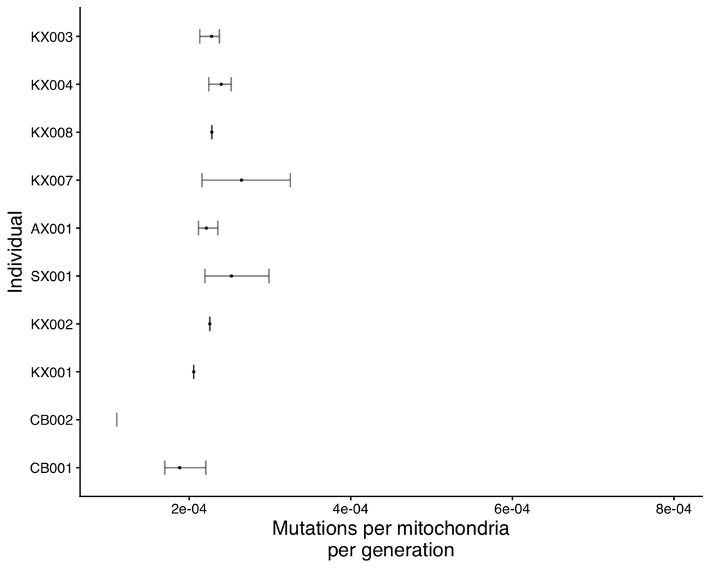

```r
abc_synres_plot_mut_rate<-abc_syn_res_df%>%
  filter(Age>=0)%>%
  ggplot(aes(x=forcats::fct_reorder(exp_ID,Age),y=`muts_per_mitochondria_per_generation_50%`,
             ymin=`muts_per_mitochondria_per_generation_2.5%`,
             ymax=`muts_per_mitochondria_per_generation_97.5%`))+
  geom_smooth(method="lm",col="black",linewidth=0.5)+
  geom_point(alpha=0.75,size=0.5)+
  geom_errorbar(width=0.3,alpha=0.5)+
  theme_classic()+
  scale_y_continuous(limits=c(1e-4,8e-4),breaks=seq(2e-4,1e-3,2e-4))+
  labs(x="Individual",y="Mutations per mitochondria\nper generation")+
  my_markdown_theme+
  coord_flip()

abc_synres_plot_mut_rate+my_markdown_theme
```

```r
save_plot(filename=paste0(plots_dir,"abc_synres_plot_mut_rate.pdf"),abc_synres_plot_mut_rate,width=1.75,height=2)
```

Now do linear mixed effects modelling using all values of the posterior distribution and using individual as a random effect.

```r
abc_syn_res_df<-lapply(1:nrow(sumstats.syn.data),function(i) {
  Exp_ID=sumstats.syn.data[i,1]
  res<-abc(target = as.numeric(sumstats.syn.data[i,VAF_categories_to_include_in_ABC]),
           param = all_sumstats[,1:2],
           sumstat = all_sumstats[,VAF_categories_to_include_in_ABC],
           tol = 0.05,
           transf = c("log","log"),
           method = "neuralnet")

  return(as.data.frame(res$adj.values)%>%mutate(exp_ID=Exp_ID$exp_ID))
})%>%dplyr::bind_rows()%>%
  left_join(ref_df%>%dplyr::select(Sample,Age),by=c("exp_ID"="Sample"))%>%
  dplyr::filter(!exp_ID%in%c("8pcw","18pcw"))
```

Perform the LMER on this “no non-synonymous mutation” results.

```r
lme.gens_by_age.syn<-lme4::lmer(total_generations~Age+(1|exp_ID),data=abc_syn_res_df)
summary(lme.gens_by_age.syn)
```

```
## Linear mixed model fit by REML ['lmerMod']
## Formula: total_generations ~ Age + (1 | exp_ID)
##    Data: abc_syn_res_df
##
## REML criterion at convergence: 28650.1
##
## Scaled residuals:
##     Min      1Q  Median      3Q     Max
## -7.1315 -0.3043  0.0007  0.2985  8.1379
##
## Random effects:
##  Groups   Name        Variance Std.Dev.
##  exp_ID   (Intercept) 10124    100.6
##  Residual              5446     73.8
## Number of obs: 2500, groups:  exp_ID, 10
##
## Fixed effects:
##             Estimate Std. Error t value
## (Intercept)  173.918     61.402   2.832
## Age           14.651      1.078  13.592
##
## Correlation of Fixed Effects:
##     (Intr)
## Age -0.855
```

```r
mtDNA_CN*365/lme.gens_by_age.syn@beta[2]
```

```
## [1] 14947.37
```

```r
mtDNA_CN*365/confint(lme.gens_by_age.syn)["Age",]
```

```
## Computing profile confidence intervals ...
```

```
##    2.5 %   97.5 %
## 17429.50 13084.07
```

Plot these results.

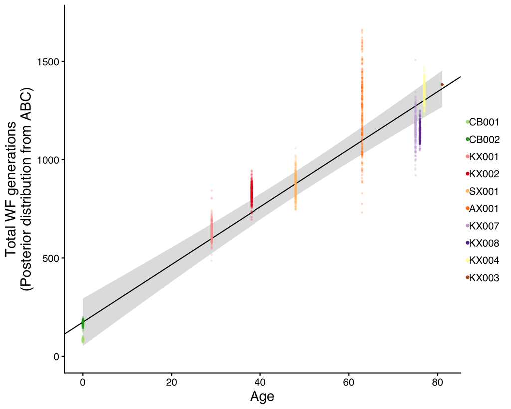

```r
#95% CI of the fitted trend - see lmer_confidence_band() for what the band covers
gens_by_age_syn_band<-lmer_confidence_band(lme.gens_by_age.syn,abc_syn_res_df,predictor="Age")

abc_synres_plot_total_generations<-abc_syn_res_df%>%
  dplyr::filter(!exp_ID%in%c("8pcw","18pcw"))%>%
  mutate(exp_ID=factor(exp_ID,levels=ref_df$Sample[order(ref_df$Age)]))%>%
  ggplot(aes(x=Age,y=total_generations))+
  geom_ribbon(data=gens_by_age_syn_band,aes(x=Age,ymin=lower,ymax=upper),
              inherit.aes=FALSE,fill="grey50",alpha=0.25)+
  geom_jitter(aes(col=exp_ID),alpha=0.1,size=0.3,height=0,width=0.1)+
  scale_y_continuous(limits=c(0,1700))+
  geom_abline(slope=lme.gens_by_age.syn@beta[2],intercept = lme.gens_by_age.syn@beta[1],linetype=1)+
  scale_color_manual(values=Individual_cols[-c(1:2)])+
  theme_classic()+
  guides(colour=guide_legend(override.aes = list(alpha=1)))+
  labs(x="Age",y="Total WF generations\n(Posterior distribution from ABC)",col="")+
  my_markdown_theme+
  theme(legend.box.spacing = unit(0,"mm"),
        legend.key.size = unit(0.5,"mm"),
        legend.spacing = unit(0,"mm"),
        legend.box.margin = margin(c(0,0,0,0)),
        legend.text = element_text(margin = margin(t=0)))
abc_synres_plot_total_generations+geom_point(aes(col=exp_ID),alpha=0.1,size=0.5)+my_markdown_theme+guides(colour=guide_legend(override.aes = list(alpha=1,size=1)))+
  theme(legend.box.spacing = unit(0,"mm"),
        legend.key.size = unit(1,"mm"),
        legend.spacing = unit(0.5,"mm"),
        legend.box.margin = margin(c(0,0,0,0)),
        legend.text = element_text(margin = margin(t=0)))
```

```r
save_plot(filename=paste0(plots_dir,"abc_synres_plot_total_generations.pdf"),abc_synres_plot_total_generations,width=2,height=2)
```

### Compare the drift rate estimates between the full mutation set and the synonymous/ non-coding set

This shows that the estimates are very similar with highly overlapping confidence intervals. Interestingly, despite being a smaller dataset, the non-coding mutation set has narrower confidence intervals and slightly lower drift parameter estimates - though clearly this is not statistically significant.

```r
lme.syn.CIs<-mtDNA_CN*365/confint(lme.gens_by_age.syn)["Age",]
```

```
## Computing profile confidence intervals ...
```

```r
lme.full.CIs<-mtDNA_CN*365/confint(lme.gens_by_age)["Age",]
```

```
## Computing profile confidence intervals ...
```

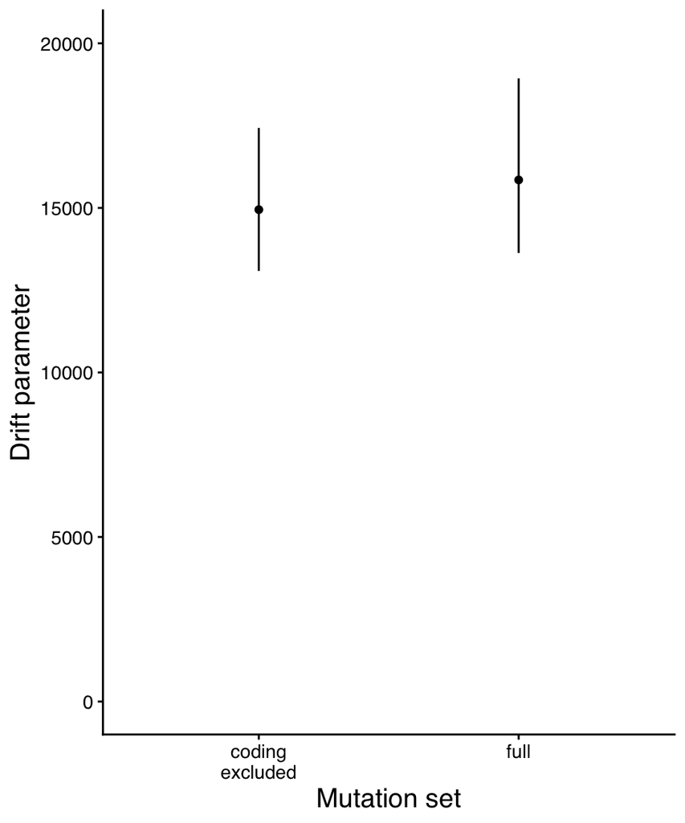

```r
lme_res_df<-data.frame(mutation_set=c("full","coding\nexcluded"),
           drift_parameter=c(mtDNA_CN*365/lme.gens_by_age@beta[2],mtDNA_CN*365/lme.gens_by_age.syn@beta[2]),
           uci=c(lme.full.CIs[1],lme.syn.CIs[1]),
           lci=c(lme.full.CIs[2],lme.syn.CIs[2]))

lme_res_df%>%
  ggplot(aes(x=mutation_set,y=drift_parameter,ymin=lci,ymax=uci))+
  geom_point()+
  geom_linerange()+
  theme_classic()+
  lims(y=c(0,20000))+
  my_markdown_theme+
  labs(x="Mutation set",y="Drift parameter")
```